# ncGTW User Manual

Chiung-Ting Wu

2019-06-15

#### Package

ncGTW 0.5.0

# 1 Introduction

Neighbor-wise Compound-specific Graphical Time Warping (ncGTW) is an alignment algorithm that can align LC-MS profiles by leveraging expected retention time (RT) drift structures and compound-specific warping functions. This algorithm is improved from graphical time warping (GTW) [1], a popular dynamic time warping (DTW) based alignment method [2]. Specifically, ncGTW uses individualized warping functions for different compounds and assigns constraint edges on warping functions of neighboring samples. That is, ncGTW avoids the popular but not accurate assumption which assumes all the m/z bins in the same sample share the same warping function. This assumption often fails when the dataset contains hundreds of samples or the data acquisition time longer than a week. Moreover, by considering the RT drifts structure, ncGTW can align RT more accurately.

`ncGTW` is an R package developed as a plug-in of `xcms`, a popular LC-MS data analysis R package [3–5]. Due to the same warping function assumption or bad parameter settings, `xcms` may have some misaligned features, and there is a function in `ncGTW` to identify such misalignments. After identifying the misaligned features, the user can realign these features with the alignment function in `ncGTW` to obtain a better alignment result for more accurate analysis, such as peak-regrouping or peak-filling with `xcms`.

# 2 Quick Start

To check there are misaligned features from `xcms` or not, one can input two `xcms` grouping results with different values of RT window parameter (`xcms` grouping parameter, `bw`) to the function `misalignDetect()`. One value of `bw` should be the expected maximal RT drift, and another should be near to the RT sampling resolution (the inverse of scan frequency). If there are some detected misaligned features, the user can decide to adjust the paramters in `xcms` or use `ncGTW` to realign them. Besides the `xcms` aligment results, the only paramter with no default in `misalignDetect()` is `ppm`, which should be set as same as `ppm` of the peak detection in `xcms`.

```r
excluGroups <- misalignDetect(xcmsLargeWin, xcmsSmallWin, ppm)
```

# 3 Misaligned Feature Detection and Realignment

## 3.1 RT Structure Incorporation

To demonstrate the workflow of ncGTW, an example dataset is included in the package. The aquisition time of the dataset is more than two weeks, in which the 20 samples are selected from a large dataset for a quick demonstration.

```r
library(xcms)
library(ncGTW)

filepath <- system.file("extdata", package = "ncGTW")
file <- list.files(filepath, pattern = "mzxml", full.names = TRUE)
# The paths of the 20 samples
```

To incorporate the RT structure, the order of the paths in `file` should be as same as the sample acquisition order (run order). In the example dataset, the index in each file name is the acquisition order, so we sort the paths according to `tempInd`. When dealing with other dataset, the user should make sure the order of the paths is as same the order of data acquisition.

```r
tempInd <- matrix(0, length(file), 1)
for (n in 1:length(file))
{
  tempCha <- file[n]
  tempLen <- nchar(tempCha)
  tempInd[n] <- as.numeric(substr(tempCha, regexpr("example", tempCha) + 7,
                                  tempLen - 6))
}
file <- file[sort.int(tempInd, index.return = TRUE)$ix]
# Sort the paths by data acquisition order to incorporate the RT structure
```

## 3.2 XCMS Preprocessing

As a plug-in, the inputs of `ncGTW` are the alignment results from `xcms`, so first we need to apply `xcms` on the dataset. The parameters should be decided by the user when dealing with other datasets.

```r
CPWmin <- 2
CPWmax <- 25
ppm <- 15
xsnthresh <- 3
LM <- F
integrate <- 2
RTerror <- 6
MZerror <- 0.05
prefilter <- c(8, 1000)
# XCMS parameters

ds <- xcmsSet(file, method = "centWave", peakwidth = c(CPWmin, CPWmax),
              ppm = ppm, noise = xsnthresh, integrate = integrate,
              prefilter = prefilter)
gds <- group(ds, mzwid = MZerror, bw = RTerror)
agds <- retcor(gds, missing = 5)
# XCMS peak detection and RT alignment
```

To detect the misaligned features, `ncGTW` needs two XCMS grouping results with different values of `bw`. The larger one should be expected maximal RT drift, and the smaller one should be the RT sampling resolution (the inverse of scan frequency).

```r
bwLarge <- RTerror
bwSmall <- 0.3
# Two different values of bw parameter

xcmsLargeWin <- group(agds, mzwid = MZerror, bw = bwLarge)
xcmsSmallWin <- group(agds, mzwid = MZerror, bw = bwSmall, minfrac = 0)
# Two resolution of XCMS grouping results
```

## 3.3 ncGTW Workflow

After XCMS preprocessing, `ncGTW` can be applied on the results. There are two major steps in `ncGTW`, misaligned feature detection and misaligned feature realignment.

### 3.3.1 Misaligned Feature Detection

To detect misaligned features, `misalignDetect()` needs two different XCMS grouping results as inputs. This function tells which features in `xcmsLargeWin` could be broken into several small features in `xcmsSmallWin`, and the detected features should be misaligned features. `ppm` is one criteria to decide the small features in `xcmsLargeWin` are from the same compounds or not, and should be set as same as the one in XCMS peak detection.

```r
excluGroups <- misalignDetect(xcmsLargeWin, xcmsSmallWin, ppm)
# Detect misaligned features
show(excluGroups)
```

```
#>      index    mzmed    mzmin    mzmax    rtmed    rtmin    rtmax npeaks
#> [1,]     1 630.5534 630.5527 630.5546 349.4897 347.2043 355.5610     14
#> [2,]     9 931.5268 931.5251 931.5275 336.6458 335.6331 339.6014     17
#>      extdata
#> [1,]      14
#> [2,]      17
```

There are two features are detected as shown in `excluGroups`. Before realigning them, the raw profile of each detected feature of each sample needs to load from the files. `loadProfile()` loads the needed information with file paths (`file`) and the detected features (`excluGroups`) as inputs.

```r
ncGTWinputs <- loadProfile(file, excluGroups)
```

```
#> Time difference of 17.81679 secs
```

```r
# Load raw profiles from the files
```

The user can also check the detected features are really misaligned or not by viewing the extracted ion chromatogram. `plotGroup()` draws the extracted ion chromatogram. `ncGTWinputs` is the loaded information from `loadProfile()`, `xcmsLargeWin@rt$corrected` is the alignment by XCMS, and `ind` is just a parameter for indexing the chromatograms. The user are free to set `ind`.

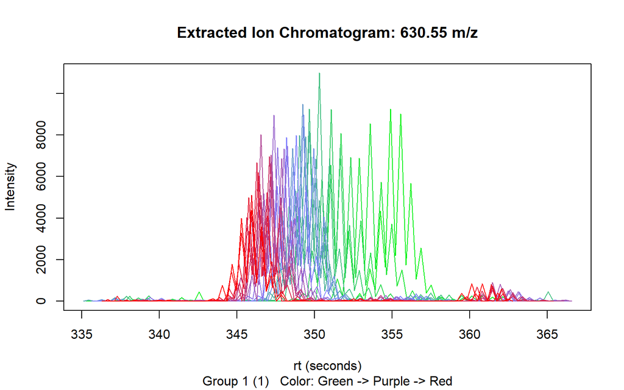

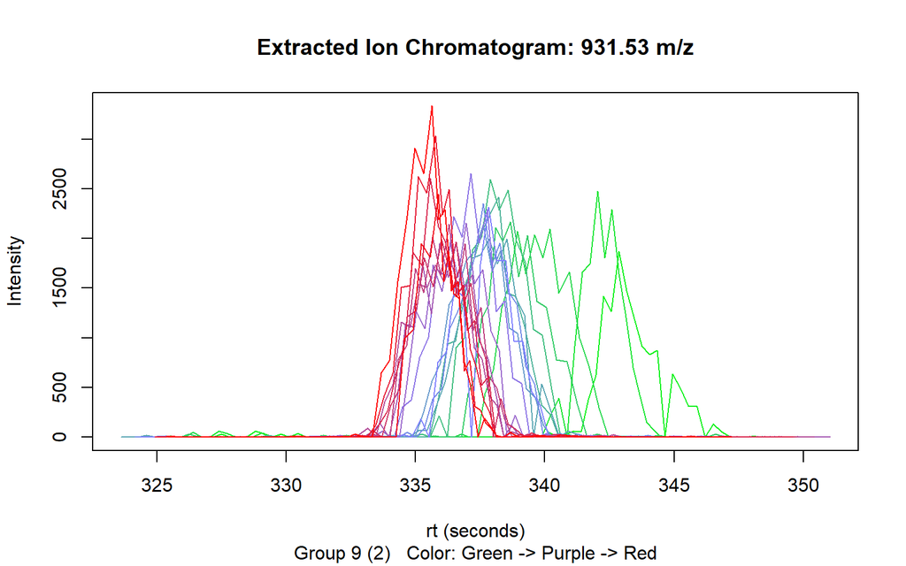

```r
for (n in 1:length(ncGTWinputs))
  plotGroup(ncGTWinputs[[n]], xcmsLargeWin@rt$corrected, ind = n)
```

```r
  # (Optional) Draw the detected misaligned features
```

From the two figures, it is clear that these two features are really misaligned. The color of curves changes from green, purple, to red according to the sample run order.

### 3.3.2 Misaligned Feature Realignment

After the needed information is loaded to `ncGTWinputs`, we can start to realign the detected features with `ncGTW`. The parameter `parSamp` is for parallel computing, which decides how many samples would be aligned together each time. In this example, there are 20 samples, and `parSamp` are set as 5. Thus, there would be four sub-groups of samples, and there are five samples in each sub-group. Also, `bpParam` is set as four workers to align the four sub-groups simultaneously. After all sub-groups are aligned, `ncGTW` would integrate the four alignment results together to generate the final realignment.

If the user do not need parallel computing, `parSamp` could be set as same as the total sample number. However, if sample number is larger than 100, it is strongly recommended to split the samples into several sub-groups.

```r
ncGTWoutputs <- vector('list', dim(excluGroups)[1])
# Prepare the output variable
for (n in 1:dim(excluGroups)[1])
  ncGTWoutputs[[n]] <- ncGTWalign(ncGTWinputs[[n]], xcmsLargeWin, parSamp = 5,
                             bpParam = SnowParam(workers = 4))
```

```
#> ncGTW is realigning group 1 ...
#> ncGTW is realigning group 9 ...
```

```r
# Perform ncGTW alignment
```

After realignment, we need to send the realignment result to `adjustRT()` to generate new RT warping functions to replace `xcmsLargeWin@rt$corrected`, and send them back to `xcms` for further analysis.

```r
ncGTWres <- xcmsLargeWin
# Prepare a new xcmsSet to contain the realignment result

ncGTWRt <- vector('list', dim(excluGroups)[1])
for (n in 1:dim(excluGroups)[1]){
  adjustRes <- adjustRT(ncGTWres, ncGTWinputs[[n]], ncGTWoutputs[[n]], ppm)
  # Generate the new warping functions
  ncGTWres@peaks <- adjustRes$peaks
  # Relocate the peaks to the new RT points according to the realignment.
  ncGTWRt[[n]] <- adjustRes$rtncGTW
  # Temporary variable for new warping functions
}
```

Again, the user can also check the realignment by viewing the extracted ion chromatogram with `plotGroup()`.

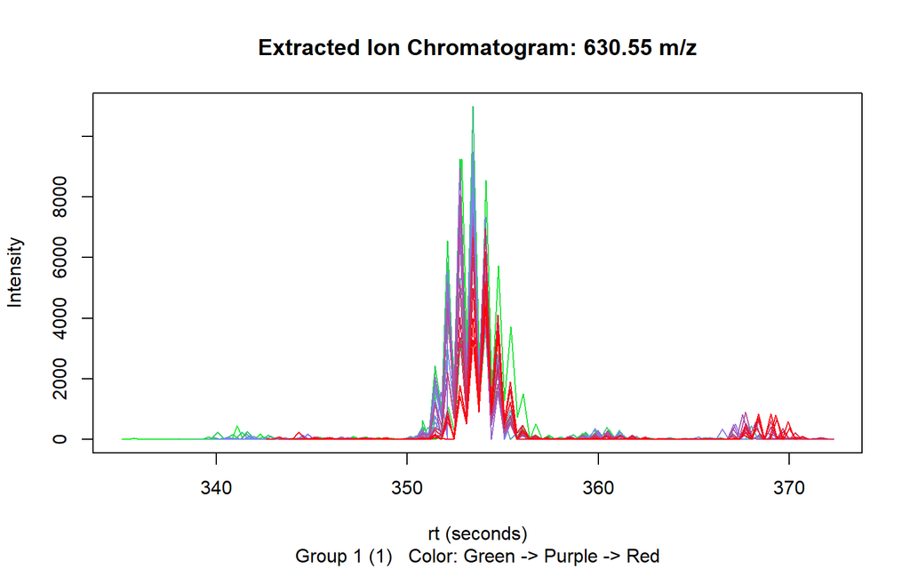

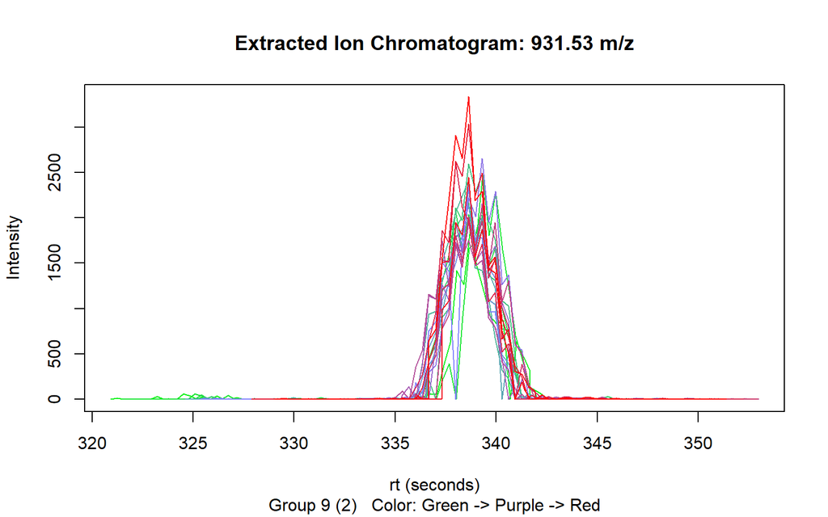

```r
for (n in 1:length(ncGTWinputs))
  plotGroup(ncGTWinputs[[n]], ncGTWRt[[n]], ind = n)
```

```r
  # (Optional) Draw the realigned features
```

From the two figures, it is clear that the two misaligned features now are realigned accurately, comparing to the XCMS alignment.

## 3.4 Peak-filling with Realigned RT

One of the most obvious impact of the realignment is the quality of peak-filling in `xcms`. Due to the more accurate warping functions, the peak-filling step has a higher change to retrieve the missing peaks back. That is, the guessing of the positions of the missing peaks becomes more accurate according to the new warping functions. Here we demonstrate the differences of peak-filling of the two misaligned features.

```r
ncGTWres@groups <- excluGroups[ , 2:9]
ncGTWres@groupidx <- xcmsLargeWin@groupidx[excluGroups[ , 1]]
# Only consider the misaligned features

ncGTWres@rt$corrected <- vector('list', length(ncGTWres@filepaths))
for (n in 1:length(ncGTWres@filepaths)){
  ncGTWres@rt$corrected[[n]] <- vector('list', dim(excluGroups)[1])
  for (m in 1:dim(ncGTWres@groups)[1])
    ncGTWres@rt$corrected[[n]][[m]] <- ncGTWRt[[m]][[n]]
}
# Replace the XCMS warping function to ncGTW warping function

XCMSres <- xcmsLargeWin
XCMSres@groups <- excluGroups[ , 2:9]
XCMSres@groupidx <- xcmsLargeWin@groupidx[excluGroups[ , 1]]
# Consider only the misaligned features with XCMS warping function
```

After extract the misaligned features and replace the old warping functions, we can apply `fillPeaks` in `xcms` for peak-filling. Since `fillPeaks` accepts only one warping function for each sample, we need to replace the function `fillPeaksChromPar()` first.

```r
assignInNamespace("fillPeaksChromPar", ncGTW:::fillPeaksChromPar, ns = "xcms",
                  envir = as.environment("package:xcms"))
# Replace fillPeaksChromPar() in XCMS

ncGTWresFilled <- fillPeaks(ncGTWres)
XCMSresFilled <- fillPeaks(XCMSres)
# Peak-filling with old and new warping functions

compCV(XCMSresFilled)
```

```
#>           [,1]
#> [1,] 0.3687170
#> [2,] 0.3514152
```

```r
compCV(ncGTWresFilled)
```

```
#>           [,1]
#> [1,] 0.2375171
#> [2,] 0.1278115
```

```r
# Compare the coefficient of variation
```

For the first misaligned feature, the coefficient of variation (CV) decreases from 0.369 to 0.238, and for the second one, the CV decreases from 0.351 to 0.128. Thus, it is very clear that new warping functions improve the quality of peak-filling significantly.

# References

1. Wang Y, Miller DJ, Poskanzer K, Wang Y, Tian L, Yu G. Graphical time warping for joint alignment of multiple curves. In: Advances in neural information processing systems 29. 2016. pp. 3648–56.

2. Sakoe H, Chiba S, Waibel A, Lee K. Dynamic programming algorithm optimization for spoken word recognition. Readings in speech recognition. 1990;159:224.

3. Smith CA, Want EJ, O’Maille G, Abagyan R, Siuzdak G. XCMS: Processing mass spectrometry data for metabolite profiling using nonlinear peak alignment, matching, and identification. Analytical chemistry. 2006;78:779–87.

4. Tautenhahn R, Boettcher C, Neumann S. Highly sensitive feature detection for high resolution lc/ms. BMC bioinformatics. 2008;9:504.

5. Benton HP, Want EJ, Ebbels TM. Correction of mass calibration gaps in liquid chromatography–mass spectrometry metabolomics data. Bioinformatics. 2010;26:2488–9.